# Mixed ANOVA: anxiety across treatment groups and timepoints

Clinical trial: CBT vs pharmacological vs control

Author

Published

17 April 2026

# Methods

A randomized clinical trial assigned 300 patients to one of three conditions: cognitive-behavioral therapy (CBT, *n* = 100), pharmacological treatment (*n* = 100), or waitlist control (*n* = 100). Anxiety was measured with the GAD-7 at three timepoints: pre-treatment, post-treatment, and 3-month follow-up.

A 3 (group: CBT vs. pharmacological vs. control) × 3 (timepoint: pre vs. post vs. follow-up) mixed ANOVA was conducted on GAD-7 scores using the `afex` R package, with Greenhouse–Geisser correction for sphericity. Post-hoc pairwise comparisons used Holm correction. Effect sizes are reported as generalized eta squared ($\eta^2_G$; Olejnik & Algina, 2003).

# Results

## Descriptive statistics

```r
descriptivos <- data_long |>
  summarise(
    M  = round(mean(anxiety), 2),
    SD = round(sd(anxiety), 2),
    n  = n(),
    .by = c(group, timepoint)
  ) |>
  arrange(group, timepoint)

descriptivos |>
  kable(
    format    = "html",
    caption   = "Table 1. Descriptive statistics for GAD-7 anxiety scores by group and timepoint.",
    col.names = c("Group", "Timepoint", "M", "SD", "n")
  )
```

Table 1. Descriptive statistics for GAD-7 anxiety scores by group and timepoint.

| Group | Timepoint | M | SD | n |
| --- | --- | --- | --- | --- |
| CBT | pre | 15.08 | 2.14 | 100 |
| CBT | post | 10.78 | 2.84 | 100 |
| CBT | followup | 11.72 | 2.97 | 100 |
| control | pre | 15.74 | 2.14 | 100 |
| control | post | 15.17 | 2.50 | 100 |
| control | followup | 14.80 | 2.91 | 100 |
| pharmacological | pre | 15.65 | 2.19 | 100 |
| pharmacological | post | 12.72 | 2.73 | 100 |
| pharmacological | followup | 15.40 | 3.08 | 100 |

## Mixed ANOVA

```r
modelo_mixto <- aov_ez(
  id      = "patient_id",
  dv      = "anxiety",
  data    = data_long,
  within  = "timepoint",
  between = "group"
)

afex::nice(modelo_mixto) |>
  kable(
    format    = "html",
    caption   = "Table 2. Mixed ANOVA results for GAD-7 anxiety: timepoint x group.",
    col.names = c("Effect", "df", "MSE", "F", "ges", "p"),
    escape    = FALSE
  )
```

Table 2. Mixed ANOVA results for GAD-7 anxiety: timepoint x group.

| Effect | df | MSE | F | ges | p |
| --- | --- | --- | --- | --- | --- |
| group | 2, 297 | 17.44 | 34.40 *** | .163 | <.001 |
| timepoint | 1.69, 501.82 | 2.00 | 303.98 *** | .142 | <.001 |
| group:timepoint | 3.38, 501.82 | 2.00 | 85.13 *** | .085 | <.001 |

The mixed ANOVA revealed significant main effects of timepoint and group, as well as a significant timepoint × group interaction (see Table 2). The interaction effect was of primary interest: it indicates that the change in anxiety over time **differed across treatment conditions**.

## Effect sizes with confidence intervals

```r
eta_squared(model = modelo_mixto, generalized = TRUE) |>
  kable(
    format  = "html",
    caption = "Table 3. Generalized eta squared with 95% confidence intervals.",
    digits  = 3
  )
```

Table 3. Generalized eta squared with 95% confidence intervals.

| Parameter | Eta2_generalized | CI | CI_low | CI_high |
| --- | --- | --- | --- | --- |
| group | 0.163 | 0.95 | 0.101 | 1 |
| timepoint | 0.142 | 0.95 | 0.101 | 1 |
| group:timepoint | 0.085 | 0.95 | 0.049 | 1 |

## Visualization

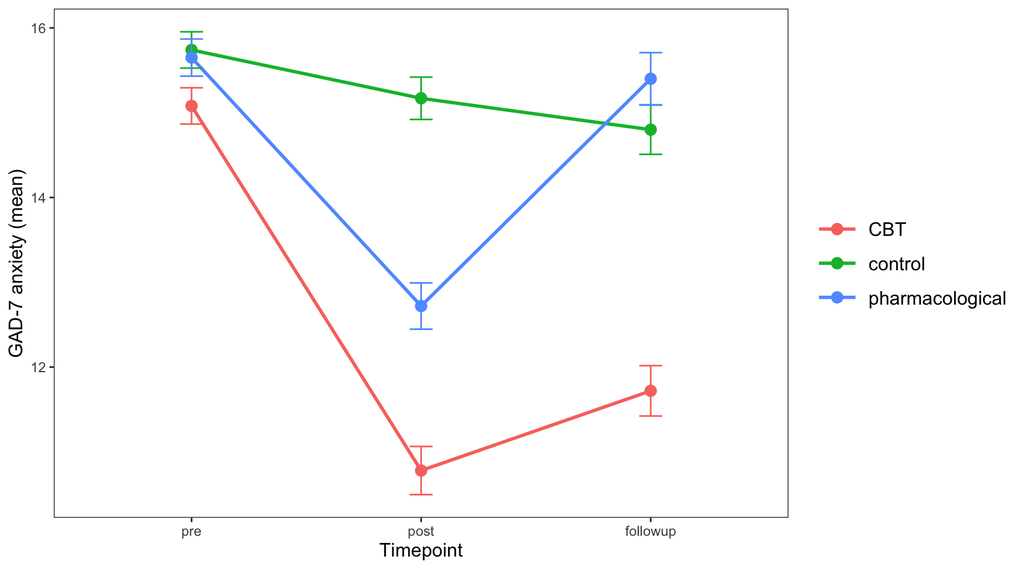

Figure 1: Figure 1. Mean GAD-7 anxiety across timepoints by treatment group. Error bars represent ±1 standard error of the mean.

```r
fig_trayectorias_anxiety <- ggplot(
  data    = descriptivos,
  mapping = aes(x = timepoint, y = M, color = group, group = group)
) +
  geom_point(size = 3) +
  geom_line(linewidth = 1) +
  geom_errorbar(
    aes(ymin = M - SD/sqrt(n), ymax = M + SD/sqrt(n)),
    width = 0.1
  ) +
  labs(
    x     = "Timepoint",
    y     = "GAD-7 anxiety (mean)",
    color = "Group"
  ) +
  theme_apa()

fig_trayectorias_anxiety

ggsave(
  filename = "../exercises/output/fig_trayectorias_anxiety.png",
  plot     = fig_trayectorias_anxiety,
  width    = 9, height = 5, dpi = 300
)
```

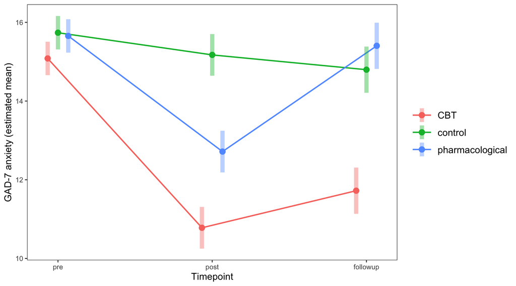

Figure 2: Figure 2. Estimated marginal means from the mixed ANOVA model (95% CI).

```r
fig_interaccion_anxiety <- emmip(
  object  = modelo_mixto,
  formula = group ~ timepoint,
  CIs     = TRUE
) +
  labs(
    x = "Timepoint",
    y = "GAD-7 anxiety (estimated mean)"
  ) +
  theme_apa()

fig_interaccion_anxiety

ggsave(
  filename = "../exercises/output/fig_interaccion_anxiety.png",
  plot     = fig_interaccion_anxiety,
  width    = 9, height = 5, dpi = 300
)
```

## Post-hoc comparisons

### Time effects within each group

```r
emm_within <- emmeans(object = modelo_mixto, specs = ~ timepoint | group)

pairs(x = emm_within, adjust = "holm") |>
  as.data.frame() |>
  kable(
    format  = "html",
    caption = "Table 4. Pairwise comparisons of timepoints within each group (Holm-corrected).",
    digits  = 3
  )
```

Table 4. Pairwise comparisons of timepoints within each group (Holm-corrected).

| contrast | group | estimate | SE | df | t.ratio | p.value |
| --- | --- | --- | --- | --- | --- | --- |
| pre - post | CBT | 4.303 | 0.161 | 297 | 26.803 | 0.000 |
| pre - followup | CBT | 3.361 | 0.219 | 297 | 15.318 | 0.000 |
| post - followup | CBT | -0.942 | 0.165 | 297 | -5.708 | 0.000 |
| pre - post | control | 0.564 | 0.161 | 297 | 3.513 | 0.001 |
| pre - followup | control | 0.940 | 0.219 | 297 | 4.284 | 0.000 |
| post - followup | control | 0.376 | 0.165 | 297 | 2.278 | 0.023 |
| pre - post | pharmacological | 2.939 | 0.161 | 297 | 18.307 | 0.000 |
| pre - followup | pharmacological | 0.251 | 0.219 | 297 | 1.144 | 0.254 |
| post - followup | pharmacological | -2.688 | 0.165 | 297 | -16.288 | 0.000 |

### Group differences at each timepoint

```r
emm_between <- emmeans(object = modelo_mixto, specs = ~ group | timepoint)

pairs(x = emm_between, adjust = "holm") |>
  as.data.frame() |>
  kable(
    format  = "html",
    caption = "Table 5. Pairwise comparisons of groups at each timepoint (Holm-corrected).",
    digits  = 3
  )
```

Table 5. Pairwise comparisons of groups at each timepoint (Holm-corrected).

| contrast | timepoint | estimate | SE | df | t.ratio | p.value |
| --- | --- | --- | --- | --- | --- | --- |
| CBT - control | pre | -0.654 | 0.305 | 297 | -2.143 | 0.099 |
| CBT - pharmacological | pre | -0.572 | 0.305 | 297 | -1.874 | 0.124 |
| control - pharmacological | pre | 0.082 | 0.305 | 297 | 0.269 | 0.788 |
| CBT - control | post | -4.393 | 0.381 | 297 | -11.539 | 0.000 |
| CBT - pharmacological | post | -1.936 | 0.381 | 297 | -5.085 | 0.000 |
| control - pharmacological | post | 2.457 | 0.381 | 297 | 6.454 | 0.000 |
| CBT - control | followup | -3.075 | 0.422 | 297 | -7.284 | 0.000 |
| CBT - pharmacological | followup | -3.682 | 0.422 | 297 | -8.722 | 0.000 |
| control - pharmacological | followup | -0.607 | 0.422 | 297 | -1.438 | 0.152 |

# Interpretation

These findings are consistent with the literature suggesting that the benefits of CBT for anxiety disorders tend to be **maintained beyond the end of active treatment**, whereas pharmacological effects may attenuate after discontinuation.

# References

Cohen, J. (1988). *Statistical power analysis for the behavioral sciences* (2nd ed.). Lawrence Erlbaum Associates.

Olejnik, S., & Algina, J. (2003). Generalized eta and omega squared statistics: Measures of effect size for some common research designs. *Psychological Methods*, *8*(4), 434–447.

Singmann, H., Bolker, B., Westfall, J., Aust, F., & Ben-Shachar, M. S. (2024). *afex: Analysis of factorial experiments* [R package]. https://CRAN.R-project.org/package=afex